# 2022_12_07_(SIMULAZIONE)_CLUSTERING,_PREPROCESSING

Find clusters for the included dataset. The solution must be produced as a Python Notebook. The notebook must include appropriate comments and must operate as follows

1. load the data and separate in X all the columns but the last one, in y the last colum, then produce a pairplot of X and comment what you see

```python
import pandas as pd
import numpy as np
import matplotlib.pyplot as plt

url="exam_2021_01_15.csv"
df = pd.read_csv(url, sep=',')
X = df.drop('y', axis=1)
y = df.drop(X.columns, axis=1)
```

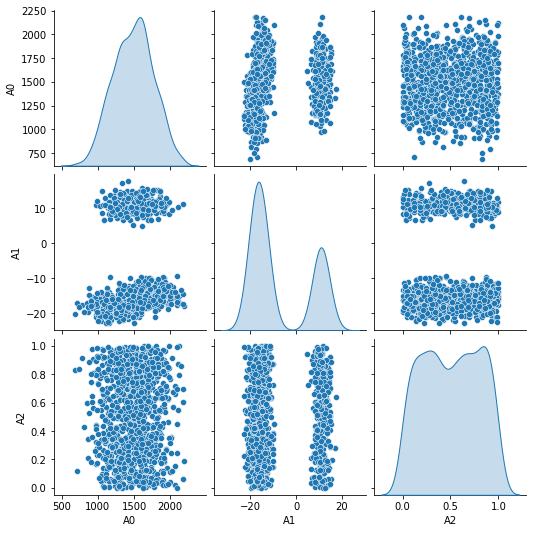

```python
import seaborn as sns

sns.pairplot(X, diag_kind='kde');
```

è chiaro come le coppie (A1,A0) e (A2,A1) siano delle perfette candidate per il clustering

1. Find the best clustering scheme for X with a method of your choice, plot the silhouette index for an appropriate range of parameters and show the chosen hyperparameter(s)

```python
from sklearn.cluster import KMeans
from sklearn.metrics import silhouette_score

random_state=1
k_range = list(range(2,11))
silhouette_scores_km=[]
for i in k_range:
    KMmodel = KMeans(n_clusters=i, random_state=random_state)
    y_km = KMmodel.fit_predict(X=X)
    silhouette_scores_km.append(silhouette_score(X=X, labels=y_km))
```

2.1 Consider carefully the number of clusters, simple optimisation of the silhouette will not be enough, decide visually the best number of clusters

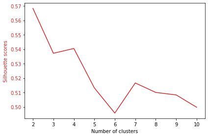

```python
# plotting silhouette scores
fig, ax = plt.subplots()
color = 'tab:red'
ax.set_xlabel('Number of clusters')
ax.set_ylabel('Silhouette scores', color=color)
ax.plot(k_range, silhouette_scores_km, color=color)
ax.tick_params(axis='y', labelcolor=color)
fig.tight_layout()
plt.show()
```

dal grafico si evince che il best_k è 2. però guardando la rappresentazione dei dati, notiamo come ci siano 3 valori distinti di cluster

```python
np.unique(y)
```

```
array([0, 1, 2])
```

1. Fit the clustering scheme, store the cluster labels in y_km and output the silhouette score

```python
best_k = 3
km = KMeans(n_clusters=best_k, random_state=random_state)
y_km = km.fit_predict(X=X)
print("number of clusters = {} - Shiluette score = {}".format(best_k,silhouette_scores_km[k_range.index(best_k)]))
```

```
number of clusters = 3 - Shiluette score = 0.5371952870200944
```

1. Use the labels in the last column of the input file as the "gold standard" for the clustering schemes with sklearn.metrics.cluster.pair_confusion_matrix

```python
from sklearn.metrics.cluster import pair_confusion_matrix
pair_confusion_matrix(y.unstack(),y_km)
```

```
array([[476192, 190474],
       [170882, 161452]])
```

1. Consider possible pre-processing actions, repeat the fitting and evaluate as before the result of the new fitting

```python
# pre-processing: normalization
from sklearn.preprocessing import MinMaxScaler # normalizzazione in un certo range
mms = MinMaxScaler(feature_range=(0,1)) # range 0-1
d = mms.fit_transform(X)
normalized_df = pd.DataFrame(d, columns=X.columns)
```

```python
# Fit the clustering scheme, store the cluster labels in y_km
km = KMeans(n_clusters = best_k, random_state = random_state)
y_km = km.fit_predict(normalized_df)

# Output the silhouette score
print("The silhouette score for best_k = {} was {}"
      .format(best_k ,silhouette_score(normalized_df,y_km)))
```

```
The silhouette score for best_k = 3 was 0.4279385440884642
```